# Project1

By: Thomas Girmay

Hello! To begin, we must first scrape the frist table from https://www.spaceweatherlive.com/en/solar-activity/top-50-solar-flares and convert it into a pandas dataframe.

```python
import requests, datetime, lxml
from bs4 import BeautifulSoup as bs
import pandas as pd
import numpy as np
solarDf = pd.read_html('https://www.spaceweatherlive.com/en/solar-activity/top-50-solar-flares')[0]
solarDf.head()
```

|  | Unnamed: 0 | Unnamed: 1 | Unnamed: 2 | Region | Start | Maximum | End | Unnamed: 7 |
| --- | --- | --- | --- | --- | --- | --- | --- | --- |
| 0 | 1 | X28.0 | 2003/11/04 | 486 | 19:29 | 19:53 | 20:06 | MovieView archive |
| 1 | 2 | X20.0 | 2001/04/02 | 9393 | 21:32 | 21:51 | 22:03 | MovieView archive |
| 2 | 3 | X17.2 | 2003/10/28 | 486 | 09:51 | 11:10 | 11:24 | MovieView archive |
| 3 | 4 | X17.0 | 2005/09/07 | 808 | 17:17 | 17:40 | 18:03 | MovieView archive |
| 4 | 5 | X14.4 | 2001/04/15 | 9415 | 13:19 | 13:50 | 13:55 | MovieView archive |

This table could use some column names so lets add some. Also, since we will not be using the movies, we can drop the column.

```python
solarDf.columns = ["Rank", "x_class", "date", "region", "start_time", "max_time", "end_time", "movie"]
del solarDf['movie']
solarDf.head()
```

|  | Rank | x_class | date | region | start_time | max_time | end_time |
| --- | --- | --- | --- | --- | --- | --- | --- |
| 0 | 1 | X28.0 | 2003/11/04 | 486 | 19:29 | 19:53 | 20:06 |
| 1 | 2 | X20.0 | 2001/04/02 | 9393 | 21:32 | 21:51 | 22:03 |
| 2 | 3 | X17.2 | 2003/10/28 | 486 | 09:51 | 11:10 | 11:24 |
| 3 | 4 | X17.0 | 2005/09/07 | 808 | 17:17 | 17:40 | 18:03 |
| 4 | 5 | X14.4 | 2001/04/15 | 9415 | 13:19 | 13:50 | 13:55 |

Next, lets consolidate the date and time columns into three columns where each time has the date attached and is a datetime object

```python
solarDf["start_time"]=pd.to_datetime(solarDf["date"] + ' ' +  solarDf["start_time"])
solarDf["max_time"]=pd.to_datetime(solarDf["date"] + ' ' +  solarDf["max_time"])
solarDf["end_time"]=pd.to_datetime(solarDf["date"] + ' ' +  solarDf["end_time"])
del solarDf["date"]
solarDf.head()
```

|  | Rank | x_class | region | start_time | max_time | end_time |
| --- | --- | --- | --- | --- | --- | --- |
| 0 | 1 | X28.0 | 486 | 2003-11-04 19:29:00 | 2003-11-04 19:53:00 | 2003-11-04 20:06:00 |
| 1 | 2 | X20.0 | 9393 | 2001-04-02 21:32:00 | 2001-04-02 21:51:00 | 2001-04-02 22:03:00 |
| 2 | 3 | X17.2 | 486 | 2003-10-28 09:51:00 | 2003-10-28 11:10:00 | 2003-10-28 11:24:00 |
| 3 | 4 | X17.0 | 808 | 2005-09-07 17:17:00 | 2005-09-07 17:40:00 | 2005-09-07 18:03:00 |
| 4 | 5 | X14.4 | 9415 | 2001-04-15 13:19:00 | 2001-04-15 13:50:00 | 2001-04-15 13:55:00 |

Let's check the datatype of the time columns.

```python
type(solarDf["start_time"][0])
type(solarDf["max_time"][0])
type(solarDf["end_time"][0])
```

```
pandas._libs.tslibs.timestamps.Timestamp
```

Timestamps are the pandas equivalent to the python datetime library. Now we can continue to format this table. Lets rename these columns since we have the date entered as well as the time and we can rearrange the columns a bit.

```python
solarDf.columns = ["Rank", "x_class", "region", "start_datetime", "max_datetime", "end_datetime"]
solarDf =solarDf[["Rank", "x_class", "start_datetime", "max_datetime", "end_datetime", "region"]]
solarDf
```

|  | Rank | x_class | start_datetime | max_datetime | end_datetime | region |
| --- | --- | --- | --- | --- | --- | --- |
| 0 | 1 | X28.0 | 2003-11-04 19:29:00 | 2003-11-04 19:53:00 | 2003-11-04 20:06:00 | 486 |
| 1 | 2 | X20.0 | 2001-04-02 21:32:00 | 2001-04-02 21:51:00 | 2001-04-02 22:03:00 | 9393 |
| 2 | 3 | X17.2 | 2003-10-28 09:51:00 | 2003-10-28 11:10:00 | 2003-10-28 11:24:00 | 486 |
| 3 | 4 | X17.0 | 2005-09-07 17:17:00 | 2005-09-07 17:40:00 | 2005-09-07 18:03:00 | 808 |
| 4 | 5 | X14.4 | 2001-04-15 13:19:00 | 2001-04-15 13:50:00 | 2001-04-15 13:55:00 | 9415 |
| 5 | 6 | X10.0 | 2003-10-29 20:37:00 | 2003-10-29 20:49:00 | 2003-10-29 21:01:00 | 486 |
| 6 | 7 | X9.4 | 1997-11-06 11:49:00 | 1997-11-06 11:55:00 | 1997-11-06 12:01:00 | 8100 |
| 7 | 8 | X9.3 | 2017-09-06 11:53:00 | 2017-09-06 12:02:00 | 2017-09-06 12:10:00 | 2673 |
| 8 | 9 | X9.0 | 2006-12-05 10:18:00 | 2006-12-05 10:35:00 | 2006-12-05 10:45:00 | 930 |
| 9 | 10 | X8.3 | 2003-11-02 17:03:00 | 2003-11-02 17:25:00 | 2003-11-02 17:39:00 | 486 |
| 10 | 11 | X8.2 | 2017-09-10 15:35:00 | 2017-09-10 16:06:00 | 2017-09-10 16:31:00 | 2673 |
| 11 | 12 | X7.1 | 2005-01-20 06:36:00 | 2005-01-20 07:01:00 | 2005-01-20 07:26:00 | 720 |
| 12 | 13 | X6.9 | 2011-08-09 07:48:00 | 2011-08-09 08:05:00 | 2011-08-09 08:08:00 | 1263 |
| 13 | 14 | X6.5 | 2006-12-06 18:29:00 | 2006-12-06 18:47:00 | 2006-12-06 19:00:00 | 930 |
| 14 | 15 | X6.2 | 2005-09-09 19:13:00 | 2005-09-09 20:04:00 | 2005-09-09 20:36:00 | 808 |
| 15 | 16 | X6.2 | 2001-12-13 14:20:00 | 2001-12-13 14:30:00 | 2001-12-13 14:35:00 | 9733 |
| 16 | 17 | X5.7 | 2000-07-14 10:03:00 | 2000-07-14 10:24:00 | 2000-07-14 10:43:00 | 9077 |
| 17 | 18 | X5.6 | 2001-04-06 19:10:00 | 2001-04-06 19:21:00 | 2001-04-06 19:31:00 | 9415 |
| 18 | 19 | X5.4 | 2012-03-07 00:02:00 | 2012-03-07 00:24:00 | 2012-03-07 00:40:00 | 1429 |
| 19 | 20 | X5.4 | 2003-10-23 08:19:00 | 2003-10-23 08:35:00 | 2003-10-23 08:49:00 | 486 |
| 20 | 21 | X5.4 | 2005-09-08 20:52:00 | 2005-09-08 21:06:00 | 2005-09-08 21:17:00 | 808 |
| 21 | 22 | X5.3 | 2001-08-25 16:23:00 | 2001-08-25 16:45:00 | 2001-08-25 17:04:00 | 9591 |
| 22 | 23 | X4.9 | 1998-08-18 22:10:00 | 1998-08-18 22:19:00 | 1998-08-18 22:28:00 | 8307 |
| 23 | 24 | X4.9 | 2014-02-25 00:39:00 | 2014-02-25 00:49:00 | 2014-02-25 01:03:00 | 1990 |
| 24 | 25 | X4.8 | 2002-07-23 00:18:00 | 2002-07-23 00:35:00 | 2002-07-23 00:47:00 | 39 |
| 25 | 26 | X4.0 | 2000-11-26 16:34:00 | 2000-11-26 16:48:00 | 2000-11-26 16:56:00 | 9236 |
| 26 | 27 | X3.9 | 1998-08-19 21:35:00 | 1998-08-19 21:45:00 | 1998-08-19 21:50:00 | 8307 |
| 27 | 28 | X3.9 | 2003-11-03 09:43:00 | 2003-11-03 09:55:00 | 2003-11-03 10:19:00 | 488 |
| 28 | 29 | X3.8 | 2005-01-17 06:59:00 | 2005-01-17 09:52:00 | 2005-01-17 10:07:00 | 720 |
| 29 | 30 | X3.7 | 1998-11-22 06:30:00 | 1998-11-22 06:42:00 | 1998-11-22 06:49:00 | 8384 |
| 30 | 31 | X3.6 | 2003-05-28 00:17:00 | 2003-05-28 00:27:00 | 2003-05-28 00:39:00 | 365 |
| 31 | 32 | X3.6 | 2004-07-16 13:49:00 | 2004-07-16 13:55:00 | 2004-07-16 14:01:00 | 649 |
| 32 | 33 | X3.6 | 2005-09-09 09:42:00 | 2005-09-09 09:59:00 | 2005-09-09 10:08:00 | 808 |
| 33 | 34 | X3.4 | 2006-12-13 02:14:00 | 2006-12-13 02:40:00 | 2006-12-13 02:57:00 | 930 |
| 34 | 35 | X3.4 | 2001-12-28 20:02:00 | 2001-12-28 20:45:00 | 2001-12-28 21:32:00 | 9767 |
| 35 | 36 | X3.3 | 1998-11-28 04:54:00 | 1998-11-28 05:52:00 | 1998-11-28 06:13:00 | 8395 |
| 36 | 37 | X3.3 | 2002-07-20 21:04:00 | 2002-07-20 21:30:00 | 2002-07-20 21:54:00 | 39 |
| 37 | 38 | X3.3 | 2013-11-05 22:07:00 | 2013-11-05 22:12:00 | 2013-11-05 22:15:00 | 1890 |
| 38 | 39 | X3.2 | 2013-05-14 00:00:00 | 2013-05-14 01:11:00 | 2013-05-14 01:20:00 | 1748 |
| 39 | 40 | X3.1 | 2014-10-24 21:07:00 | 2014-10-24 21:41:00 | 2014-10-24 22:13:00 | 2192 |
| 40 | 41 | X3.1 | 2002-08-24 00:49:00 | 2002-08-24 01:12:00 | 2002-08-24 01:31:00 | 69 |
| 41 | 42 | X3.0 | 2002-07-15 19:59:00 | 2002-07-15 20:08:00 | 2002-07-15 20:14:00 | 30 |
| 42 | 43 | X2.8 | 1998-08-18 08:14:00 | 1998-08-18 08:24:00 | 1998-08-18 08:32:00 | 8307 |
| 43 | 44 | X2.8 | 2001-12-11 07:58:00 | 2001-12-11 08:08:00 | 2001-12-11 08:14:00 | 9733 |
| 44 | 45 | X2.8 | 2013-05-13 15:48:00 | 2013-05-13 16:05:00 | 2013-05-13 16:16:00 | 1748 |
| 45 | 46 | X2.7 | 2015-05-05 22:05:00 | 2015-05-05 22:11:00 | 2015-05-05 22:15:00 | 2339 |
| 46 | 47 | X2.7 | 1998-05-06 07:58:00 | 1998-05-06 08:09:00 | 1998-05-06 08:20:00 | 8210 |
| 47 | 48 | X2.7 | 2003-11-03 01:09:00 | 2003-11-03 01:30:00 | 2003-11-03 01:45:00 | 488 |
| 48 | 49 | X2.6 | 2005-01-15 22:25:00 | 2005-01-15 23:02:00 | 2005-01-15 23:31:00 | 720 |
| 49 | 50 | X2.6 | 1997-11-27 12:59:00 | 1997-11-27 13:17:00 | 1997-11-27 13:20:00 | 8113 |

```python
solarDf.dtypes
```

```
Rank                       int64
x_class                   object
start_datetime    datetime64[ns]
max_datetime      datetime64[ns]
end_datetime      datetime64[ns]
region                     int64
dtype: object
```

Now our table is ready to be used for analysis!

# NASA Data

Now, we will need to grab NASA's table on solar flares and make it useable. First, let's scrape the table, drop the columns we don't need, then rename the remaining colums appropriatley https://cdaw.gsfc.nasa.gov/CME_list/radio/waves_type2.html

```python
response = requests.get('https://cdaw.gsfc.nasa.gov/CME_list/radio/waves_type2.html')
soup = BeautifulSoup(response.content, 'html.parser').getText().split("\n")
soup = soup[15:-4]
rowsList = []
for element in soup:
    rowsList.append(element.split())
rowsList
nasaDf = pd.DataFrame(rowsList)
for i in range (14,24):
    del nasaDf[i]
nasaDf.columns = ["start_date", "start_time", "end_date",
                  "end_time", "start_frequency", "end_frequency",
                  "flare_location", "flare_region","importance",
                 "cme_date", "cme_time", "cpa",
                  "width", "speed" ]

nasaDf.head()
```

|  | start_date | start_time | end_date | end_time | start_frequency | end_frequency | flare_location | flare_region | importance | cme_date | cme_time | cpa | width | speed |
| --- | --- | --- | --- | --- | --- | --- | --- | --- | --- | --- | --- | --- | --- | --- |
| 0 | 1997/04/01 | 14:00 | 04/01 | 14:15 | 8000 | 4000 | S25E16 | 8026 | M1.3 | 04/01 | 15:18 | 74 | 79 | 312 |
| 1 | 1997/04/07 | 14:30 | 04/07 | 17:30 | 11000 | 1000 | S28E19 | 8027 | C6.8 | 04/07 | 14:27 | Halo | 360 | 878 |
| 2 | 1997/05/12 | 05:15 | 05/14 | 16:00 | 12000 | 80 | N21W08 | 8038 | C1.3 | 05/12 | 05:30 | Halo | 360 | 464 |
| 3 | 1997/05/21 | 20:20 | 05/21 | 22:00 | 5000 | 500 | N05W12 | 8040 | M1.3 | 05/21 | 21:00 | 263 | 165 | 296 |
| 4 | 1997/09/23 | 21:53 | 09/23 | 22:16 | 6000 | 2000 | S29E25 | 8088 | C1.4 | 09/23 | 22:02 | 133 | 155 | 712 |

If we were to look at the whole dataframe, we can see that observations with no values have different ways of being input across the frame. To make this table less painful to use, we will replace them all with the numpy.nan or enforce the preexisting convention.

```python
nasaDf.replace('---', np.nan, inplace=True)
nasaDf.replace('----', np.nan, inplace=True)
nasaDf.replace('-----', np.nan, inplace=True)
nasaDf.replace('------', np.nan, inplace=True)
nasaDf.replace('--/--', np.nan, inplace=True)
nasaDf.replace('--:--', np.nan, inplace=True)
nasaDf.replace('????', np.nan, inplace=True)
nasaDf.replace('???', np.nan, inplace=True)

nasaDf.replace('DSF', 'FILA', inplace=True)
nasaDf.replace('DSF', 'FILA', inplace=True)
nasaDf.replace('BACK', "Back", inplace=True)
nasaDf.replace('Back?', "Back", inplace=True)
```

Now that our missing values are uniform, we can move on to the next step in tidying our table. The CPA column includes the angle of the flares except halo flares which are just denoted by Halo. We should put that information in a separate column and fill in NaNs for the angles of the Halo flares.

```python
isFlare = []

for flare in nasaDf["cpa"]:
    if flare == 'Halo':
        isFlare.append(False)
    else:
        isFlare.append(True)
nasaDf["is_halo"] = isFlare
nasaDf.replace('Halo', np.nan, inplace=True)

nasaDf.head()
```

|  | start_date | start_time | end_date | end_time | start_frequency | end_frequency | flare_location | flare_region | importance | cme_date | cme_time | cpa | width | speed | is_halo |
| --- | --- | --- | --- | --- | --- | --- | --- | --- | --- | --- | --- | --- | --- | --- | --- |
| 0 | 1997/04/01 | 14:00 | 04/01 | 14:15 | 8000 | 4000 | S25E16 | 8026 | M1.3 | 04/01 | 15:18 | 74 | 79 | 312 | True |
| 1 | 1997/04/07 | 14:30 | 04/07 | 17:30 | 11000 | 1000 | S28E19 | 8027 | C6.8 | 04/07 | 14:27 | NaN | 360 | 878 | False |
| 2 | 1997/05/12 | 05:15 | 05/14 | 16:00 | 12000 | 80 | N21W08 | 8038 | C1.3 | 05/12 | 05:30 | NaN | 360 | 464 | False |
| 3 | 1997/05/21 | 20:20 | 05/21 | 22:00 | 5000 | 500 | N05W12 | 8040 | M1.3 | 05/21 | 21:00 | 263 | 165 | 296 | True |
| 4 | 1997/09/23 | 21:53 | 09/23 | 22:16 | 6000 | 2000 | S29E25 | 8088 | C1.4 | 09/23 | 22:02 | 133 | 155 | 712 | True |

```python
isLowerBound = []

for value in nasaDf["width"]:
    if str(value)[0] == '>' and pd.isnull(value) == False:
        value = value[1:]
        isLowerBound.append(True)
    else:
        isLowerBound.append(False)
nasaDf["is_lower_bound"] = isLowerBound
nasaDf.head()
```

|  | start_date | start_time | end_date | end_time | start_frequency | end_frequency | flare_location | flare_region | importance | cme_date | cme_time | cpa | width | speed | is_halo | is_lower_bound |
| --- | --- | --- | --- | --- | --- | --- | --- | --- | --- | --- | --- | --- | --- | --- | --- | --- |
| 0 | 1997/04/01 | 14:00 | 04/01 | 14:15 | 8000 | 4000 | S25E16 | 8026 | M1.3 | 04/01 | 15:18 | 74 | 79 | 312 | True | False |
| 1 | 1997/04/07 | 14:30 | 04/07 | 17:30 | 11000 | 1000 | S28E19 | 8027 | C6.8 | 04/07 | 14:27 | NaN | 360 | 878 | False | False |
| 2 | 1997/05/12 | 05:15 | 05/14 | 16:00 | 12000 | 80 | N21W08 | 8038 | C1.3 | 05/12 | 05:30 | NaN | 360 | 464 | False | False |
| 3 | 1997/05/21 | 20:20 | 05/21 | 22:00 | 5000 | 500 | N05W12 | 8040 | M1.3 | 05/21 | 21:00 | 263 | 165 | 296 | True | False |
| 4 | 1997/09/23 | 21:53 | 09/23 | 22:16 | 6000 | 2000 | S29E25 | 8088 | C1.4 | 09/23 | 22:02 | 133 | 155 | 712 | True | False |

Lastly, we need to convert the dates and times into datetime objects and combine the columns like with the first dataset.

```python
nasaDf.replace('24:00', '23:59', inplace=True)

years = []
for date in nasaDf["start_date"]:
    years.append(date[0:4])
nasaDf["year"] = pd.DataFrame(years)

nasaDf["start_datetime"]=pd.to_datetime(nasaDf["start_date"] + ' ' +  nasaDf["start_time"])
nasaDf["end_datetime"]=pd.to_datetime(nasaDf["year"] + ' ' + nasaDf["end_date"] + ' ' +  nasaDf["end_time"])
nasaDf["cme_datetime"]=pd.to_datetime(nasaDf["year"] + ' ' + nasaDf["cme_date"] + ' ' +  nasaDf["cme_time"])
del nasaDf["year"], nasaDf["end_date"], nasaDf["cme_date"], nasaDf["end_time"],nasaDf["cme_time"],nasaDf["start_date"], nasaDf["start_time"]
nasaDf = nasaDf[["start_datetime", "end_datetime", "start_frequency","end_frequency",  "flare_location",
                  "flare_region","importance",
                  "cme_datetime", "cpa","width",
                  "speed", "is_halo", "is_lower_bound"
                   ]]

nasaDf
```

|  | start_datetime | end_datetime | start_frequency | end_frequency | flare_location | flare_region | importance | cme_datetime | cpa | width | speed | is_halo | is_lower_bound |
| --- | --- | --- | --- | --- | --- | --- | --- | --- | --- | --- | --- | --- | --- |
| 0 | 1997-04-01 14:00:00 | 1997-04-01 14:15:00 | 8000 | 4000 | S25E16 | 8026 | M1.3 | 1997-04-01 15:18:00 | 74 | 79 | 312 | True | False |
| 1 | 1997-04-07 14:30:00 | 1997-04-07 17:30:00 | 11000 | 1000 | S28E19 | 8027 | C6.8 | 1997-04-07 14:27:00 | NaN | 360 | 878 | False | False |
| 2 | 1997-05-12 05:15:00 | 1997-05-14 16:00:00 | 12000 | 80 | N21W08 | 8038 | C1.3 | 1997-05-12 05:30:00 | NaN | 360 | 464 | False | False |
| 3 | 1997-05-21 20:20:00 | 1997-05-21 22:00:00 | 5000 | 500 | N05W12 | 8040 | M1.3 | 1997-05-21 21:00:00 | 263 | 165 | 296 | True | False |
| 4 | 1997-09-23 21:53:00 | 1997-09-23 22:16:00 | 6000 | 2000 | S29E25 | 8088 | C1.4 | 1997-09-23 22:02:00 | 133 | 155 | 712 | True | False |
| 5 | 1997-11-03 05:15:00 | 1997-11-03 12:00:00 | 14000 | 250 | S20W13 | 8100 | C8.6 | 1997-11-03 05:28:00 | 240 | 109 | 227 | True | False |
| 6 | 1997-11-03 10:30:00 | 1997-11-03 11:30:00 | 14000 | 5000 | S16W21 | 8100 | M4.2 | 1997-11-03 11:11:00 | 233 | 122 | 352 | True | False |
| 7 | 1997-11-04 06:00:00 | 1997-11-05 04:30:00 | 14000 | 100 | S14W33 | 8100 | X2.1 | 1997-11-04 06:10:00 | NaN | 360 | 785 | False | False |
| 8 | 1997-11-06 12:20:00 | 1997-11-07 08:30:00 | 14000 | 100 | S18W63 | 8100 | X9.4 | 1997-11-06 12:10:00 | NaN | 360 | 1556 | False | False |
| 9 | 1997-11-27 13:30:00 | 1997-11-27 14:00:00 | 14000 | 7000 | N17E63 | 8113 | X2.6 | 1997-11-27 13:56:00 | 98 | 91 | 441 | True | False |
| 10 | 1997-12-12 22:45:00 | 1997-12-12 23:20:00 | 14000 | 8000 | N25W52 | 8116 | B9.4 | 1997-12-13 00:26:00 | 278 | 73 | 191 | True | False |
| 11 | 1998-01-25 15:03:00 | 1998-01-25 15:18:00 | 14000 | 10000 | N21E25 | 8141 | C1.1 | 1998-01-25 15:26:00 | NaN | 360 | 693 | False | False |
| 12 | 1998-03-29 03:40:00 | 1998-03-29 03:52:00 | 14000 | 7000 | SW90 | NaN | NaN | 1998-03-29 03:48:00 | NaN | 360 | 1397 | False | False |
| 13 | 1998-04-20 10:25:00 | 1998-04-22 06:00:00 | 10000 | 35 | S22W90 | 8194 | M1.4 | 1998-04-20 10:07:00 | 284 | 165 | 1863 | True | False |
| 14 | 1998-04-23 06:00:00 | 1998-04-23 15:30:00 | 14000 | 200 | S17E90 | 8210 | X1.2 | 1998-04-23 05:55:00 | NaN | 360 | 1691 | False | False |
| 15 | 1998-04-24 09:17:00 | 1998-04-24 09:25:00 | 4700 | 2600 | S10E90 | 8210 | C8.9 | 1998-04-24 08:55:00 | 100 | 84 | 1184 | True | False |
| 16 | 1998-04-27 09:20:00 | 1998-04-27 10:00:00 | 10000 | 1000 | S16E50 | 8210 | X1.0 | 1998-04-27 08:56:00 | NaN | 360 | 1385 | False | False |
| 17 | 1998-04-29 16:30:00 | 1998-04-29 17:00:00 | 10000 | 2000 | S18E20 | 8210 | M6.8 | 1998-04-29 16:58:00 | NaN | 360 | 1374 | False | False |
| 18 | 1998-05-02 14:25:00 | 1998-05-02 14:50:00 | 5000 | 3000 | S15W15 | 8210 | X1.1 | 1998-05-02 14:06:00 | NaN | 360 | 938 | False | False |
| 19 | 1998-05-06 08:25:00 | 1998-05-06 08:35:00 | 14000 | 5000 | S11W65 | 8210 | X2.7 | 1998-05-06 08:29:00 | 309 | 190 | 1099 | True | False |
| 20 | 1998-05-09 03:35:00 | 1998-05-09 10:00:00 | 9000 | 400 | S14W89 | 8210 | M7.7 | 1998-05-09 03:35:00 | 262 | 178 | 2331 | True | False |
| 21 | 1998-05-11 21:40:00 | 1998-05-11 22:00:00 | 10000 | 1000 | N32W90 | 8214 | B6.6 | 1998-05-11 21:55:00 | 208 | >301 | 830 | True | True |
| 22 | 1998-05-19 10:00:00 | 1998-05-19 11:30:00 | 14000 | 3000 | N29W46 | 8222 | B7.9 | 1998-05-19 10:27:00 | 268 | 139 | 801 | True | False |
| 23 | 1998-05-27 13:30:00 | 1998-05-27 14:20:00 | 4000 | 1000 | N19W62 | 8226 | C7.5 | 1998-05-27 13:45:00 | 175 | 268 | 878 | True | False |
| 24 | 1998-06-11 10:15:00 | 1998-06-11 10:20:00 | 8000 | 4000 | N16E86 | 8243 | M1.4 | 1998-06-11 10:28:00 | 123 | 177 | 1223 | True | False |
| 25 | 1998-06-16 18:20:00 | 1998-06-17 21:00:00 | 12000 | 50 | S22W90 | 8232 | M1.0 | 1998-06-16 18:27:00 | 341 | 281 | 1484 | True | False |
| 26 | 1998-06-20 19:39:00 | 1998-06-20 20:00:00 | 2600 | 1800 | Back | NaN | NaN | 1998-06-20 18:20:00 | NaN | 360 | 964 | False | False |
| 27 | 1998-06-22 07:15:00 | 1998-06-22 09:20:00 | 6000 | 2000 | N16W46 | 8243 | C2.9 | 1998-06-22 05:01:00 | 265 | 59 | 206 | True | False |
| 28 | 1998-11-02 14:00:00 | 1998-11-02 14:40:00 | 14000 | 4000 | S25E47 | 8373 | C4.4 | 1998-11-02 14:18:00 | 116 | 169 | 661 | True | False |
| 29 | 1998-11-05 22:00:00 | 1998-11-07 08:00:00 | 5000 | 50 | N22W18 | 8375 | M8.4 | 1998-11-05 20:44:00 | NaN | 360 | 1118 | False | False |
| ... | ... | ... | ... | ... | ... | ... | ... | ... | ... | ... | ... | ... | ... |
| 481 | 2014-12-21 12:05:00 | 2014-12-21 12:28:00 | 14000 | 7400 | S14W25 | 12241 | M1.0 | 2014-12-21 12:12:00 | NaN | 360 | 669 | False | False |
| 482 | 2015-03-03 02:33:00 | 2015-03-03 02:37:00 | 8100 | 3600 | W90b | 12290 | M8.2 | 2015-03-03 01:48:00 | 329 | 213 | 764 | True | False |
| 483 | 2015-03-06 08:00:00 | 2015-03-06 11:30:00 | 4700 | 200 | S20E87 | 12297 | M1.5 | 2015-03-06 07:12:00 | 83 | 155 | 880 | True | False |
| 484 | 2015-03-10 00:10:00 | 2015-03-10 00:27:00 | 14000 | 6200 | S18E45 | 12297 | M5.8 | 2015-03-10 00:00:00 | NaN | 360 | 995 | False | False |
| 485 | 2015-03-11 10:30:00 | 2015-03-11 14:50:00 | 1000 | 250 | S15E23 | 12297 | M2.6 | 2015-03-11 08:24:00 | 62 | 93 | 530 | True | False |
| 486 | 2015-03-24 09:00:00 | 2015-03-06 11:47:00 | 14000 | 400 | SW90b | NaN | NaN | 2015-03-24 08:24:00 | NaN | 360 | 1794 | False | False |
| 487 | 2015-04-26 03:21:00 | 2015-04-26 03:33:00 | 8000 | 4600 | W90b | NaN | NaN | 2015-04-26 03:24:00 | NaN | 360 | 820 | False | False |
| 488 | 2015-05-05 22:24:00 | 2015-05-05 23:14:00 | 14000 | 500 | N15E79 | 12339 | X2.7 | 2015-05-05 22:24:00 | NaN | 360 | 715 | False | False |
| 489 | 2015-05-12 03:00:00 | 2015-05-12 03:04:00 | 14000 | 6400 | W90b | NaN | NaN | 2015-05-12 02:48:00 | 286 | 250 | 772 | True | False |
| 490 | 2015-06-09 20:23:00 | 2015-06-09 22:35:00 | 2300 | 200 | S03E25 | 12364 | C2.8 | 2015-06-09 20:12:00 | 77 | 262 | 1036 | True | False |
| 491 | 2015-06-14 05:26:00 | 2015-06-14 05:41:00 | 3000 | 1250 | S12W34 | 12365 | C5.9 | 2015-06-14 04:12:00 | 199 | 195 | 1228 | True | False |
| 492 | 2015-06-18 17:42:00 | 2015-06-18 19:40:00 | 3700 | 500 | N15E50 | 12371 | M3.0 | 2015-06-18 17:24:00 | NaN | 360 | 1305 | False | False |
| 493 | 2015-06-21 02:33:00 | 2015-06-21 21:20:00 | 5500 | 150 | N12E13 | 12371 | M2.0 | 2015-06-21 02:36:00 | NaN | 360 | 1366 | False | False |
| 494 | 2015-06-22 18:20:00 | 2015-06-22 21:55:00 | 14000 | 300 | N12W08 | 12371 | M6.5 | 2015-06-22 18:36:00 | NaN | 360 | 1209 | False | False |
| 495 | 2015-06-25 08:35:00 | 2015-06-25 16:30:00 | 14000 | 150 | N09W42 | 12371 | M7.9 | 2015-06-25 08:36:00 | NaN | 360 | 1627 | False | False |
| 496 | 2015-07-01 16:08:00 | 2015-07-01 20:47:00 | 1000 | 150 | W90b | NaN | NaN | 2015-07-01 14:36:00 | NaN | 360 | 1435 | False | False |
| 497 | 2015-08-22 07:07:00 | 2015-08-22 07:18:00 | 14000 | 7300 | S15E13 | 12403 | M1.2 | 2015-08-22 07:12:00 | NaN | 360 | 547 | False | False |
| 498 | 2015-09-18 04:54:00 | 2015-09-18 09:52:00 | 14000 | 400 | S21W10 | 12415 | C2.6 | 2015-09-18 05:00:00 | 201 | 131 | 823 | True | False |
| 499 | 2015-09-20 18:23:00 | 2015-09-21 01:46:00 | 14000 | 300 | S20W24 | 12415 | M2.1 | 2015-09-20 18:12:00 | NaN | 360 | 1239 | False | False |
| 500 | 2015-11-04 14:07:00 | 2015-11-04 15:14:00 | 14000 | 440 | N09W04 | 12443 | M3.7 | 2015-11-04 14:48:00 | NaN | 360 | 578 | False | False |
| 501 | 2015-11-09 13:21:00 | 2015-11-09 13:27:00 | 14000 | 9000 | S11E41 | 12449 | M3.9 | 2015-11-09 13:25:00 | 142 | 273 | 1041 | True | False |
| 502 | 2015-12-16 08:45:00 | 2015-12-16 08:57:00 | 5300 | 3800 | S13W04 | 12468 | C6.6 | 2015-12-16 09:36:00 | NaN | 360 | 579 | False | False |
| 503 | 2015-12-23 01:18:00 | 2015-12-23 01:23:00 | 12000 | 6700 | S22E63 | 12473 | M4.7 | 2015-12-23 01:25:00 | 98 | 89 | 520 | True | False |
| 504 | 2015-12-28 11:50:00 | 2015-12-28 21:45:00 | 14000 | 180 | S23W11 | 12473 | M1.8 | 2015-12-28 12:12:00 | NaN | 360 | 1212 | False | False |
| 505 | 2016-01-02 00:55:00 | 2016-01-02 03:08:00 | 1100 | 300 | S25W82 | 12473 | M2.3 | 2016-01-01 23:24:00 | NaN | 360 | 1730 | False | False |
| 506 | 2016-02-05 20:28:00 | 2016-02-05 23:31:00 | 1650 | 500 | NaN | NaN | NaN | NaT | NaN | NaN | NaN | True | False |
| 507 | 2016-02-05 22:35:00 | 2016-02-05 22:55:00 | 5200 | 1900 | NaN | NaN | NaN | 2016-02-05 21:24:00 | 193 | 155 | 445 | True | False |
| 508 | 2016-05-04 14:20:00 | 2016-05-04 14:34:00 | 14000 | 10500 | N06W61 | 12535 | C1.3 | 2016-05-04 14:12:00 | 255 | 134 | 390 | True | False |
| 509 | 2016-05-24 17:00:00 | 2016-05-24 20:50:00 | 1500 | 700 | NaN | NaN | NaN | NaT | NaN | NaN | NaN | True | False |
| 510 | 2016-08-15 18:21:00 | 2016-08-15 18:28:00 | 11000 | 3400 | NaN | NaN | NaN | 2016-08-15 17:24:00 | 75 | 98 | 633 | True | False |

511 rows × 13 columns

```python
nasaDf.dtypes
```

```
start_datetime     datetime64[ns]
end_datetime       datetime64[ns]
start_frequency            object
end_frequency              object
flare_location             object
flare_region               object
importance                 object
cme_datetime       datetime64[ns]
cpa                        object
width                      object
speed                      object
is_halo                      bool
is_lower_bound               bool
dtype: object
```

# Analysis

Now that our tables are cleaned up, we can begin some analysis! First, lets compare our two datasets by editing the NASA dataset a bit. We can index by the importance column and take the first 50 observations to create another top 50 list.

```python
top50Df = nasaDf.set_index("importance")
top50Df.sort_values("importance", ascending=False,inplace=True)
top50Df = top50Df.head(50)
top50Df.head(10)
```

| importance | start_datetime | end_datetime | start_frequency | end_frequency | flare_location | flare_region | cme_datetime | cpa | width | speed | is_halo | is_lower_bound |
| --- | --- | --- | --- | --- | --- | --- | --- | --- | --- | --- | --- | --- |
| X9.4 | 1997-11-06 12:20:00 | 1997-11-07 08:30:00 | 14000 | 100 | S18W63 | 8100 | 1997-11-06 12:10:00 | NaN | 360 | 1556 | False | False |
| X9.0 | 2006-12-05 10:50:00 | 2006-12-05 20:00:00 | 14000 | 250 | S07E68 | 10930 | NaT | NaN | NaN | NaN | True | False |
| X8.3 | 2003-11-02 17:30:00 | 2003-11-03 01:00:00 | 12000 | 250 | S14W56 | 10486 | 2003-11-02 17:30:00 | NaN | 360 | 2598 | False | False |
| X7.1 | 2005-01-20 07:15:00 | 2005-01-20 16:30:00 | 14000 | 25 | N14W61 | 10720 | 2005-01-20 06:54:00 | NaN | 360 | 882 | False | False |
| X6.9 | 2011-08-09 08:20:00 | 2011-08-09 08:35:00 | 16000 | 4000 | N17W69 | 11263 | 2011-08-09 08:12:00 | NaN | 360 | 1610 | False | False |
| X6.5 | 2006-12-06 19:00:00 | 2006-12-08 23:59:00 | 16000 | 30 | S05E64 | 10930 | NaT | NaN | NaN | NaN | True | False |
| X6.2 | 2005-09-09 19:45:00 | 2005-09-09 22:00:00 | 10000 | 50 | S12E67 | 10808 | 2005-09-09 19:48:00 | NaN | 360 | 2257 | False | False |
| X5.7 | 2000-07-14 10:30:00 | 2000-07-15 14:30:00 | 14000 | 80 | N22W07 | 9077 | 2000-07-14 10:54:00 | NaN | 360 | 1674 | False | False |
| X5.6 | 2001-04-06 19:35:00 | 2001-04-07 01:50:00 | 14000 | 230 | S21E31 | 9415 | 2001-04-06 19:30:00 | NaN | 360 | 1270 | False | False |
| X5.4 | 2012-03-07 01:00:00 | 2012-03-08 19:00:00 | 16000 | 30 | N17E27 | 11429 | 2012-03-07 00:24:00 | NaN | 360 | 2684 | False | False |

```python
rankList = []

for index1, top50 in top50Df.iterrows():
    i =0
    for index2, solar in solarDf.iterrows():
        i+= 1
        if index1 == solar["x_class"] and top50["start_datetime"].year == solar["start_datetime"].year:
            rankList.append(solar["Rank"])
            break
        elif i > 49:
            rankList.append(np.nan)
top50Df["solar_rank"]= rankList
top50Df = top50Df[pd.isnull(top50Df["solar_rank"])== False]
top50Df
```

| importance | start_datetime | end_datetime | start_frequency | end_frequency | flare_location | flare_region | cme_datetime | cpa | width | speed | is_halo | is_lower_bound | solar_rank |
| --- | --- | --- | --- | --- | --- | --- | --- | --- | --- | --- | --- | --- | --- |
| X9.4 | 1997-11-06 12:20:00 | 1997-11-07 08:30:00 | 14000 | 100 | S18W63 | 8100 | 1997-11-06 12:10:00 | NaN | 360 | 1556 | False | False | 7.0 |
| X9.0 | 2006-12-05 10:50:00 | 2006-12-05 20:00:00 | 14000 | 250 | S07E68 | 10930 | NaT | NaN | NaN | NaN | True | False | 9.0 |
| X8.3 | 2003-11-02 17:30:00 | 2003-11-03 01:00:00 | 12000 | 250 | S14W56 | 10486 | 2003-11-02 17:30:00 | NaN | 360 | 2598 | False | False | 10.0 |
| X7.1 | 2005-01-20 07:15:00 | 2005-01-20 16:30:00 | 14000 | 25 | N14W61 | 10720 | 2005-01-20 06:54:00 | NaN | 360 | 882 | False | False | 12.0 |
| X6.9 | 2011-08-09 08:20:00 | 2011-08-09 08:35:00 | 16000 | 4000 | N17W69 | 11263 | 2011-08-09 08:12:00 | NaN | 360 | 1610 | False | False | 13.0 |
| X6.5 | 2006-12-06 19:00:00 | 2006-12-08 23:59:00 | 16000 | 30 | S05E64 | 10930 | NaT | NaN | NaN | NaN | True | False | 14.0 |
| X6.2 | 2005-09-09 19:45:00 | 2005-09-09 22:00:00 | 10000 | 50 | S12E67 | 10808 | 2005-09-09 19:48:00 | NaN | 360 | 2257 | False | False | 15.0 |
| X5.7 | 2000-07-14 10:30:00 | 2000-07-15 14:30:00 | 14000 | 80 | N22W07 | 9077 | 2000-07-14 10:54:00 | NaN | 360 | 1674 | False | False | 17.0 |
| X5.6 | 2001-04-06 19:35:00 | 2001-04-07 01:50:00 | 14000 | 230 | S21E31 | 9415 | 2001-04-06 19:30:00 | NaN | 360 | 1270 | False | False | 18.0 |
| X5.4 | 2012-03-07 01:00:00 | 2012-03-08 19:00:00 | 16000 | 30 | N17E27 | 11429 | 2012-03-07 00:24:00 | NaN | 360 | 2684 | False | False | 19.0 |
| X5.3 | 2001-08-25 16:50:00 | 2001-08-25 23:00:00 | 8000 | 170 | S17E34 | 9591 | 2001-08-25 16:50:00 | NaN | 360 | 1433 | False | False | 22.0 |
| X4.9 | 2014-02-25 00:56:00 | 2014-02-25 11:28:00 | 14000 | 100 | S13E82 | 11990 | 2014-02-25 01:25:00 | NaN | 360 | 2147 | False | False | 24.0 |
| X4.8 | 2002-07-23 00:50:00 | 2002-07-23 04:00:00 | 11000 | 400 | S13E72 | 10039 | 2002-07-23 00:42:00 | NaN | 360 | 2285 | False | False | 25.0 |
| X4.0 | 2000-11-26 17:00:00 | 2000-11-26 17:15:00 | 14000 | 7000 | N18W38 | 9236 | 2000-11-26 17:06:00 | NaN | 360 | 980 | False | False | 26.0 |
| X3.9 | 2003-11-03 10:00:00 | 2003-11-03 12:30:00 | 6000 | 400 | N08W77 | 10488 | 2003-11-03 10:06:00 | 293 | 103 | 1420 | True | False | 28.0 |
| X3.8 | 2005-01-17 10:00:00 | 2005-01-17 10:35:00 | 6100 | 1500 | N15W25 | 10720 | 2005-01-17 09:54:00 | NaN | 360 | 2547 | False | False | 29.0 |
| X3.6 | 2003-05-28 01:00:00 | 2003-05-29 00:30:00 | 1000 | 200 | S06W21 | 10365 | 2003-05-28 00:50:00 | NaN | 360 | 1366 | False | False | 31.0 |
| X3.4 | 2001-12-28 20:35:00 | 2001-12-29 03:00:00 | 14000 | 350 | S26E90 | 9756 | 2001-12-28 20:30:00 | NaN | 360 | 2216 | False | False | 35.0 |
| X3.4 | 2006-12-13 02:45:00 | 2006-12-13 10:40:00 | 12000 | 150 | S06W23 | 10930 | 2006-12-13 02:54:00 | NaN | 360 | 1774 | False | False | 34.0 |
| X3.3 | 2002-07-20 21:30:00 | 2002-07-20 22:20:00 | 10000 | 2000 | SE90b | 10039 | 2002-07-20 22:06:00 | NaN | 360 | 1941 | False | False | 37.0 |
| X3.2 | 2013-05-14 01:16:00 | 2013-05-14 02:35:00 | 16000 | 700 | N08E77 | 11748 | 2013-05-14 01:25:00 | NaN | 360 | 2625 | False | False | 39.0 |
| X3.1 | 2002-08-24 01:45:00 | 2002-08-24 03:25:00 | 5000 | 400 | S02W81 | 10069 | 2002-08-24 01:27:00 | NaN | 360 | 1913 | False | False | 41.0 |
| X2.8 | 2013-05-13 16:15:00 | 2013-05-13 19:10:00 | 16000 | 300 | N11E85 | 11748 | 2013-05-13 16:07:00 | NaN | 360 | 1850 | False | False | 45.0 |
| X2.7 | 1998-05-06 08:25:00 | 1998-05-06 08:35:00 | 14000 | 5000 | S11W65 | 8210 | 1998-05-06 08:29:00 | 309 | 190 | 1099 | True | False | 47.0 |
| X2.7 | 2015-05-05 22:24:00 | 2015-05-05 23:14:00 | 14000 | 500 | N15E79 | 12339 | 2015-05-05 22:24:00 | NaN | 360 | 715 | False | False | 46.0 |
| X2.7 | 2003-11-03 01:15:00 | 2003-11-03 01:25:00 | 3000 | 1500 | N10W83 | 10488 | 2003-11-03 01:59:00 | 304 | 65 | 827 | True | False | 48.0 |
| X2.6 | 2005-01-15 23:00:00 | 2005-01-15 00:00:00 | 3000 | 40 | N15W05 | 10720 | 2005-01-15 23:06:00 | NaN | 360 | 2861 | False | False | 49.0 |
| X2.6 | 1997-11-27 13:30:00 | 1997-11-27 14:00:00 | 14000 | 7000 | N17E63 | 8113 | 1997-11-27 13:56:00 | 98 | 91 | 441 | True | False | 50.0 |

# Visualizations

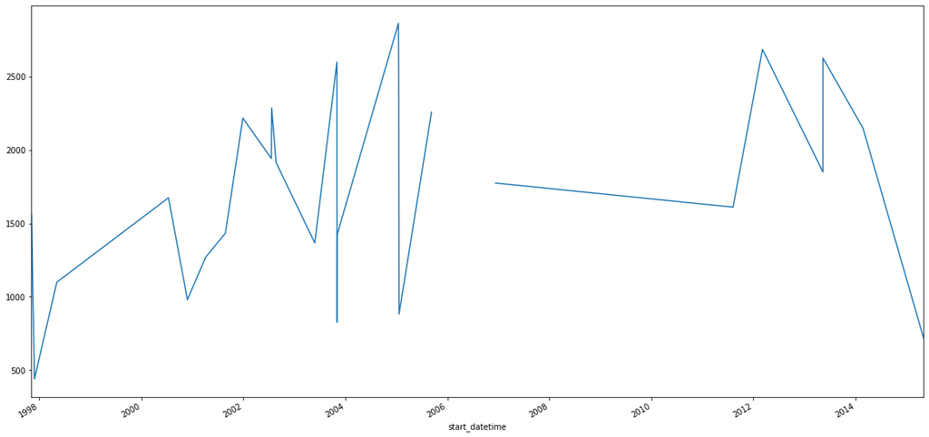

```python
top50Df["speed"] = pd.to_numeric(top50Df["speed"], errors = 'coerce')
top50ByDate = top50Df.set_index("start_datetime")
top50ByDate["speed"].plot.line(figsize=(20,10))
```

Next, lets see how many of these solar flares were halos using a pie chart

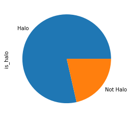

```python
top50ByDate.is_halo.value_counts().plot.pie(labels = ["Halo", "Not Halo"])
```

Next, lets check to see the number of flares per month

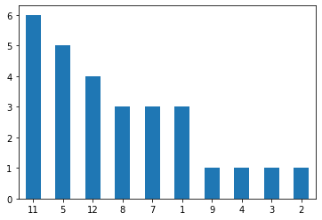

```python
monthsList = []
for index, row in top50Df.iterrows():
    monthsList.append(row["start_datetime"].month)
top50ByDate["month"] = monthsList

top50ByDate.month.value_counts().plot.bar(x= "month", rot=0)
```